# Descriptives and Demographics

# Descriptives

## Overall

### BFI df

```r
clean_data_bfi %>%
  select(where(is.numeric)) %>%
  psych::describe()
```

```
##                               vars    n   mean      sd median trimmed    mad
## duration                         1 8056 824.54 1052.77 629.50  700.75 260.20
## eli_self_1                       2 8056   3.72    1.06   4.00    3.82   1.48
## eli_self_2                       3 8056   4.12    0.95   4.00    4.28   1.48
## eli_self_3                       4 8056   2.84    1.49   3.00    2.80   1.48
## eli_self_4                       5 8056   3.38    1.46   4.00    3.48   1.48
## eli_self_5                       6 8056   3.39    0.98   3.00    3.41   1.48
## eli_self_6                       7 8056   2.83    1.50   3.00    2.79   1.48
## eli_self_7                       8 8056   2.70    1.52   2.00    2.62   1.48
## eli_self_8                       9 8056   3.77    1.20   4.00    3.91   1.48
## eli_self_9                      10 8056   3.26    1.27   3.00    3.33   1.48
## eli_self_10                     11 8056   4.29    0.95   5.00    4.47   0.00
## eli_stereo_1                    12 8056   3.23    1.15   3.00    3.25   1.48
## eli_stereo_2                    13 8056   4.04    0.87   4.00    4.09   1.48
## eli_stereo_3                    14 8056   2.18    1.06   2.00    2.07   1.48
## eli_stereo_4                    15 8056   3.58    1.00   3.00    3.63   1.48
## eli_stereo_5                    16 8056   2.94    0.79   3.00    2.98   0.00
## eli_stereo_6                    17 8056   2.57    1.03   3.00    2.54   1.48
## eli_stereo_7                    18 8056   1.97    1.02   2.00    1.86   1.48
## eli_stereo_8                    19 8056   3.26    1.09   3.00    3.28   1.48
## eli_stereo_9                    20 8056   3.87    1.08   4.00    3.99   1.48
## eli_stereo_10                   21 8056   2.21    1.06   2.00    2.11   1.48
## distance_coffee                 22 8056   3.60    1.14   4.00    3.69   1.48
## distance_town                   23 8056   3.56    1.70   3.00    3.38   1.48
## realistic_q                     24 8056   2.77    1.09   3.00    2.84   1.48
## symbolic_q                      25 8056   2.62    1.15   3.00    2.64   1.48
## explicit_targ                   26 8056   2.19    1.12   2.00    2.11   1.48
## explicit_group                  27 8056   3.14    0.95   3.00    3.26   1.48
## eli_targ_1                      28 8056   3.21    0.94   3.00    3.25   1.48
## eli_targ_2                      29 8056   3.76    0.72   4.00    3.73   0.00
## eli_targ_3                      30 8056   2.90    1.13   3.00    2.91   1.48
## eli_targ_4                      31 8056   3.67    1.08   4.00    3.76   1.48
## eli_targ_5                      32 8056   3.47    0.79   3.00    3.47   1.48
## eli_targ_6                      33 8056   2.85    0.94   3.00    2.87   1.48
## eli_targ_7                      34 8056   2.43    1.14   2.00    2.36   1.48
## eli_targ_8                      35 8056   2.39    0.94   2.00    2.35   1.48
## eli_targ_9                      36 8056   3.14    0.94   3.00    3.11   0.00
## eli_targ_10                     37 8056   3.65    1.17   4.00    3.78   1.48
## pol_orient_1                    38 8056   1.74    0.76   2.00    1.63   1.48
## pol_orient_2                    39 8056   1.57    0.80   1.00    1.40   0.00
```

[output cut: 61 more lines]

```
## us_location_prolific            1.00     1.00     0   NaN      NaN  0.00
## international_travel_prolific   1.00     1.00     0   NaN      NaN  0.00
## bfi_number                      1.00    19.00    18  0.00    -1.21  0.06
## bfi_self                        1.00     5.00     4 -0.47    -1.01  0.01
## bfi_stereo                      1.00     5.00     4  0.37    -0.89  0.01
## bfi_targ                        1.00     5.00     4 -0.23    -0.75  0.01
## bfi_self_mp                     3.48     3.48     0  -Inf      NaN  0.00
## bfi_stereo_mp                   2.59     2.59     0  -Inf      NaN  0.00
## bfi_targ_mp                     3.16     3.16     0   Inf      NaN  0.00
## bfi_self_gmc                   -2.48     1.52     4 -0.47    -1.01  0.01
## bfi_stereo_gmc                 -1.59     2.41     4  0.37    -0.89  0.01
## bfi_targ_gmc                   -2.16     1.84     4 -0.23    -0.75  0.01
## bfi_self_pmc                   -2.48     1.52     4 -0.47    -1.01  0.01
## bfi_stereo_pmc                 -1.59     2.41     4  0.37    -0.89  0.01
## bfi_targ_pmc                   -2.16     1.84     4 -0.23    -0.75  0.01
```

### ELI df

```r
clean_data_eli %>%
  select(where(is.numeric)) %>%
  psych::describe()
```

```
##                               vars    n   mean      sd median trimmed    mad
## duration                         1 4240 824.54 1052.83 629.50  700.72 260.20
## bfi_self_1                       2 4240   3.60    1.25   4.00    3.74   1.48
## bfi_self_2                       3 4240   4.23    0.93   4.00    4.40   1.48
## bfi_self_3                       4 4240   2.55    1.40   2.00    2.43   1.48
## bfi_self_4                       5 4240   3.51    1.43   4.00    3.64   1.48
## bfi_self_5                       6 4240   4.27    0.94   5.00    4.43   0.00
## bfi_self_6                       7 4240   2.75    1.24   3.00    2.72   1.48
## bfi_self_7                       8 4240   2.29    1.20   2.00    2.22   1.48
## bfi_self_8                       9 4240   3.06    1.39   3.00    3.07   1.48
## bfi_self_9                      10 4240   2.98    1.46   3.00    2.97   1.48
## bfi_self_10                     11 4240   1.97    1.09   2.00    1.81   1.48
## bfi_self_11                     12 4240   2.90    1.21   3.00    2.87   1.48
## bfi_self_12                     13 4240   3.32    1.20   4.00    3.39   1.48
## bfi_self_13                     14 4240   4.17    0.91   4.00    4.31   1.48
## bfi_self_14                     15 4240   3.33    1.29   4.00    3.40   1.48
## bfi_self_15                     16 4240   3.75    1.08   4.00    3.87   1.48
## bfi_self_16                     17 4240   3.39    1.26   4.00    3.48   1.48
## bfi_self_17                     18 4240   2.24    1.21   2.00    2.12   1.48
## bfi_self_18                     19 4240   1.70    0.97   1.00    1.52   0.00
## bfi_self_19                     20 4240   3.72    1.02   4.00    3.82   1.48
## bfi_ster_1                      21 4240   1.59    0.83   1.00    1.44   0.00
## bfi_ster_2                      22 4240   1.80    0.95   2.00    1.66   1.48
## bfi_ster_3                      23 4240   3.31    0.98   3.00    3.33   1.48
## bfi_ster_4                      24 4240   2.99    1.22   3.00    2.99   1.48
## bfi_ster_5                      25 4240   1.93    0.92   2.00    1.84   1.48
## bfi_ster_6                      26 4240   3.35    1.18   4.00    3.44   1.48
## bfi_ster_7                      27 4240   4.45    0.81   5.00    4.62   0.00
## bfi_ster_8                      28 4240   3.00    0.92   3.00    3.00   0.00
## bfi_ster_9                      29 4240   2.67    0.99   3.00    2.68   1.48
## bfi_ster_10                     30 4240   3.87    1.13   4.00    4.01   1.48
## bfi_ster_11                     31 4240   3.43    1.00   3.00    3.47   1.48
## bfi_ster_12                     32 4240   1.78    0.93   2.00    1.63   1.48
## bfi_ster_13                     33 4240   2.32    1.04   2.00    2.23   1.48
## bfi_ster_14                     34 4240   1.99    1.05   2.00    1.83   1.48
## bfi_ster_15                     35 4240   2.14    1.06   2.00    2.02   1.48
## bfi_ster_16                     36 4240   2.51    1.09   2.00    2.46   1.48
## bfi_ster_17                     37 4240   3.95    0.95   4.00    4.06   1.48
## bfi_ster_18                     38 4240   4.12    0.91   4.00    4.23   1.48
## bfi_ster_19                     39 4240   2.25    1.16   2.00    2.12   1.48
```

[output cut: 115 more lines]

```
## us_location_prolific            1.00     1.00     0.0   NaN      NaN  0.00
## international_travel_prolific   1.00     1.00     0.0   NaN      NaN  0.00
## eli_number                      1.00    10.00     9.0  0.00    -1.23  0.04
## eli_self                        1.00     5.00     4.0 -0.50    -0.97  0.02
## eli_stereo                      1.00     5.00     4.0 -0.03    -0.87  0.02
## eli_targ                        1.00     5.00     4.0 -0.21    -0.53  0.02
## eli_self_mp                     1.40     4.80     3.4 -0.32     0.69  0.01
## eli_stereo_mp                   1.40     4.10     2.7 -0.16     0.65  0.01
## eli_targ_mp                     1.40     4.30     2.9 -0.20     1.44  0.01
## eli_self_gmc                   -2.42     1.58     4.0 -0.50    -0.97  0.02
## eli_stereo_gmc                 -1.98     2.02     4.0 -0.03    -0.87  0.02
## eli_targ_gmc                   -2.14     1.86     4.0 -0.21    -0.53  0.02
## eli_self_pmc                   -3.40     3.00     6.4 -0.44    -0.74  0.02
## eli_stereo_pmc                 -3.00     3.60     6.6  0.02    -0.56  0.02
## eli_targ_pmc                   -3.10     3.60     6.7 -0.15    -0.16  0.02
```

## Normality - Histograms

### Threat measures

#### Symbolic

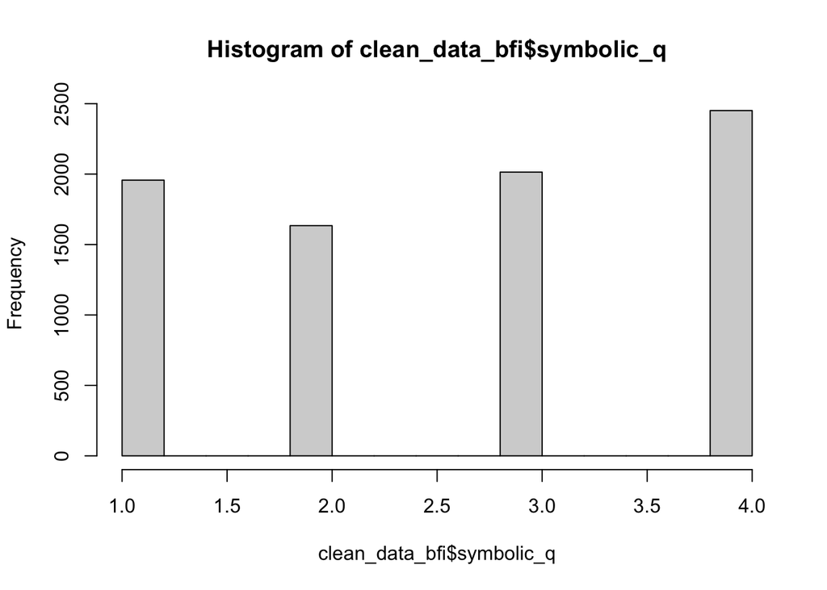

```r
hist(clean_data_bfi$symbolic_q)
```

Almost flat - if there were more response options, it may have been bi-modal. Highest point is 4 and then 1 and 3 are close to the same. Not the same as in the Pilot… the CFA may not replicate.

#### Realistic

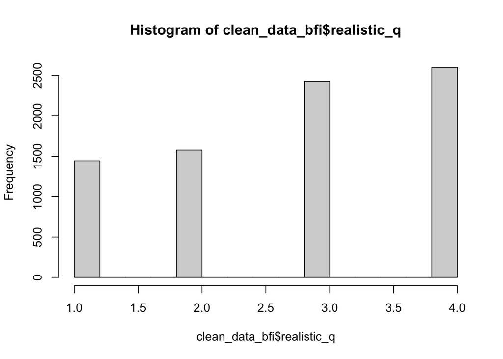

```r
hist(clean_data_bfi$realistic_q)
```

Left-skewed, more similar to the Pilot than symbolic. Not concerning skew.

#### Distance - coffee

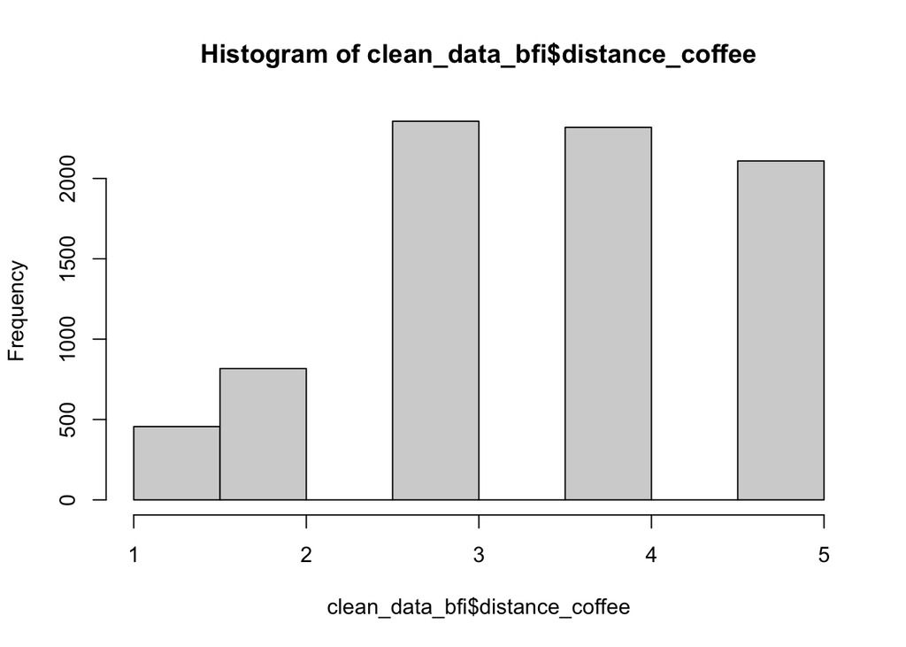

```r
hist(clean_data_bfi$distance_coffee)
```

Left-Skewed but with some respones at 1 and 2, should be robust enough in GLM

#### Distance - town

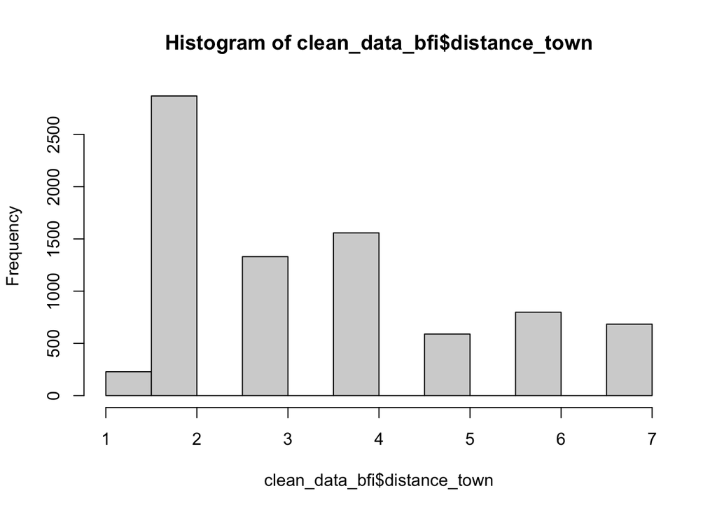

```r
hist(clean_data_bfi$distance_town)
```

Right-skewed, but really that most people responded to “2” and then it flattens out. Not a normal curve but not missing responses, should be robust enough.

#### Explicit - target

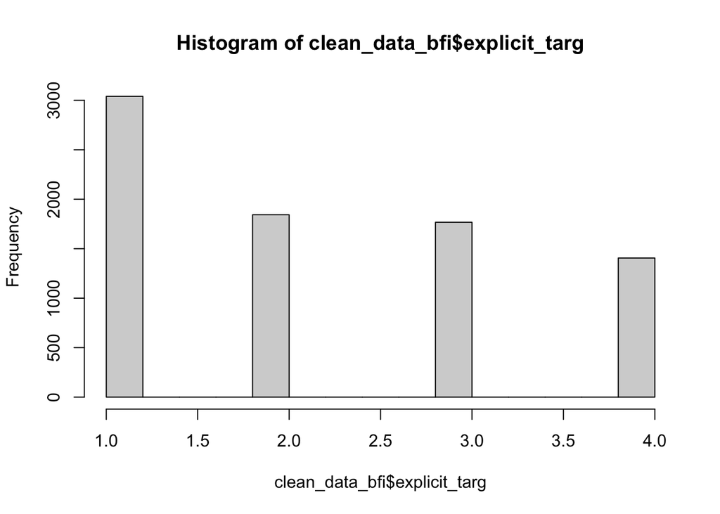

```r
hist(clean_data_bfi$explicit_targ)
```

Right-skewed… Different than pilot, but pilot was more flat, with slightly higher 1s and 2s (may have looked like this with more participants).

#### Explicit - group

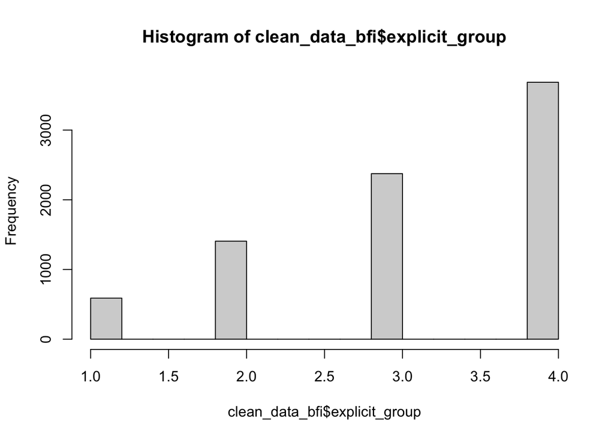

```r
hist(clean_data_bfi$explicit_group)
```

Left-skewed… same as pilot.

### BFI

#### Self

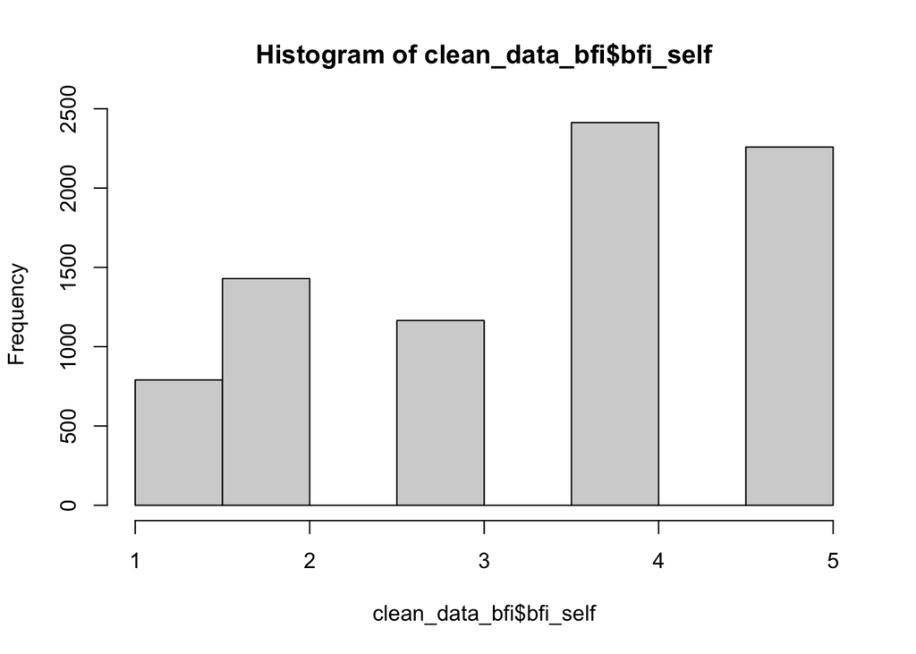

```r
hist(clean_data_bfi$bfi_self)
```

#### Stereo

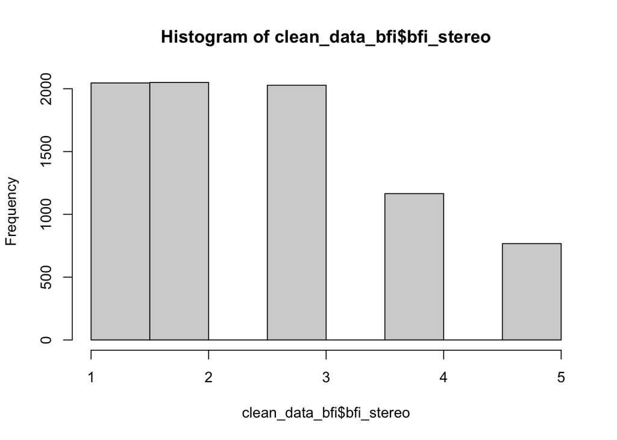

```r
hist(clean_data_bfi$bfi_stereo)
```

#### Target

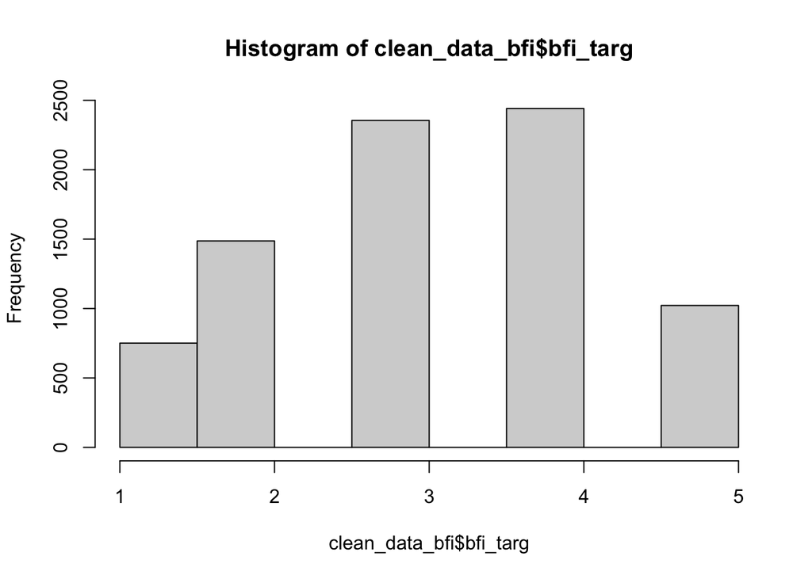

```r
hist(clean_data_bfi$bfi_targ)
```

### ELI

#### Self

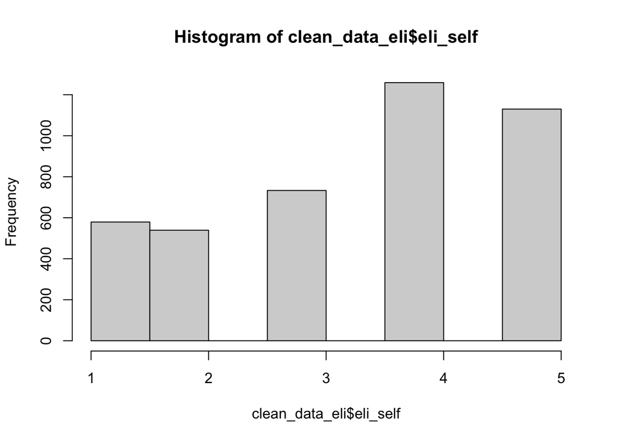

```r
hist(clean_data_eli$eli_self)
```

Skewed for the self but normal for stereo and targ - interesting!

#### Stereo

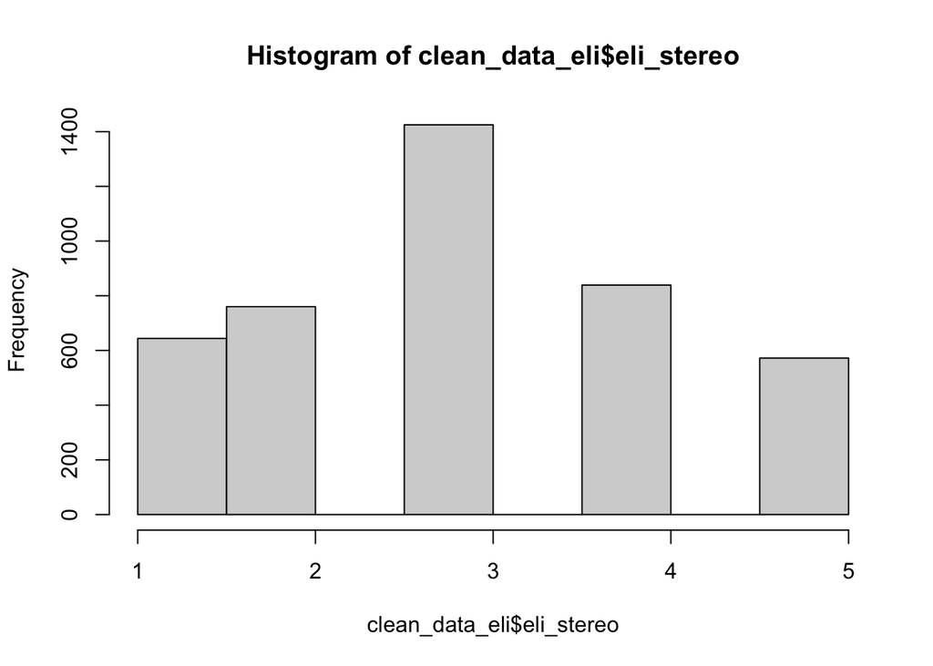

```r
hist(clean_data_eli$eli_stereo)
```

#### Targ

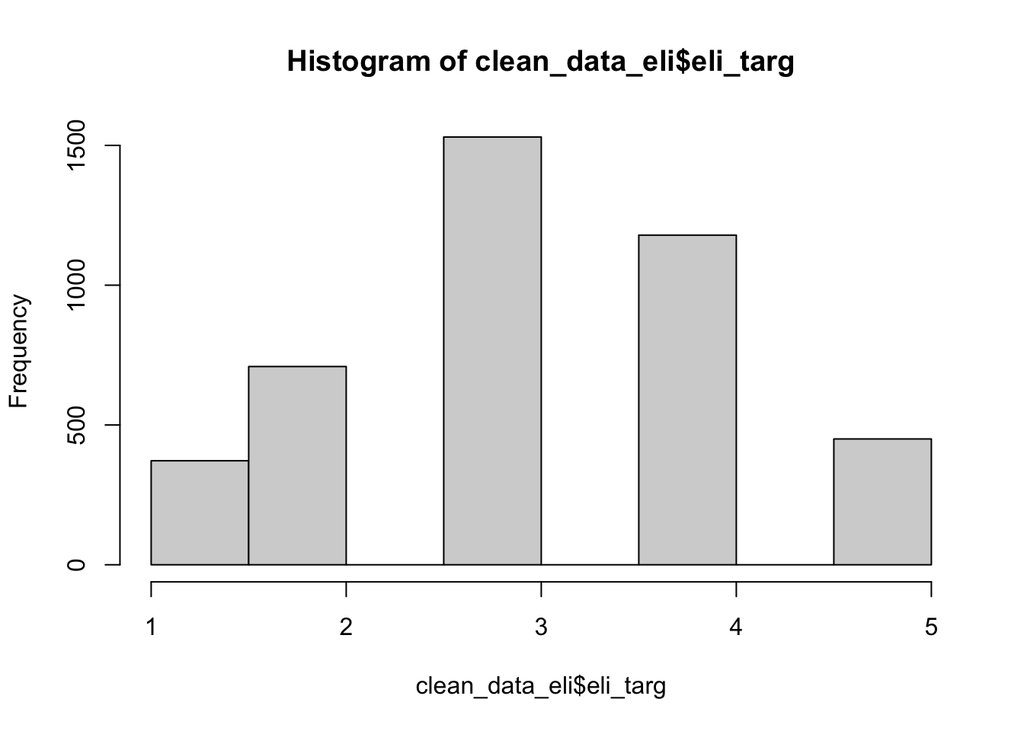

```r
hist(clean_data_eli$eli_targ)
```

### Political Orientation

#### Overall

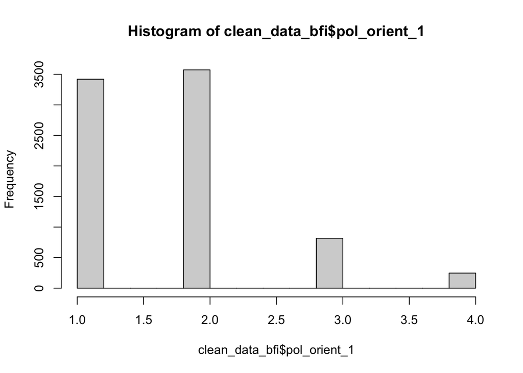

```r
hist(clean_data_bfi$pol_orient_1)
```

```r
clean_data_bfi %>%
  select(sub_id, pol_orient_1) %>%
  unique() %>%
  group_by(pol_orient_1) %>%
  count()
```

```
## # A tibble: 4 × 2
## # Groups:   pol_orient_1 [4]
##   pol_orient_1     n
##          <dbl> <int>
## 1            1   180
## 2            2   188
## 3            3    43
## 4            4    13
```

Right/positive-skewed, more severe than in the pilot (missing option 5). Would need to transform if used as a predictor.

#### Social

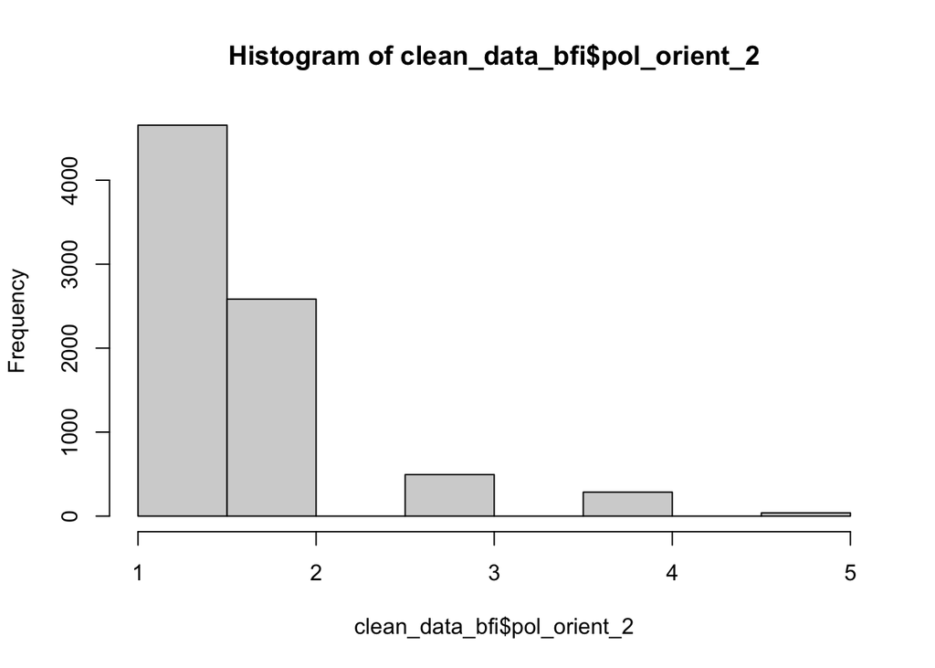

```r
hist(clean_data_bfi$pol_orient_2)
```

#### Economic

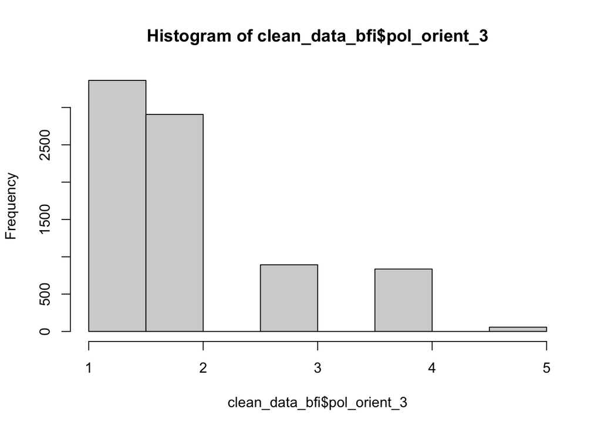

```r
hist(clean_data_bfi$pol_orient_3)
```

Some 5 responses but minimal, very skewed, should still transform.

## Outliers - percentiles

### BFI

#### Self

```r
get_outlier_number(clean_data_bfi$bfi_self)
```

```
## integer(0)
```

#### Stereo

```r
get_outlier_number(clean_data_bfi$bfi_stereo)
```

```
## integer(0)
```

#### Target

```r
get_outlier_number(clean_data_bfi$bfi_targ)
```

```
## integer(0)
```

### ELI

#### Self

```r
get_outlier_number(clean_data_eli$eli_self)
```

```
## integer(0)
```

#### Stereo

```r
get_outlier_number(clean_data_eli$eli_stereo)
```

```
## integer(0)
```

#### Target

```r
get_outlier_number(clean_data_eli$eli_targ)
```

```
## integer(0)
```

### Threat measures

#### Realistic

```r
get_outlier_number(clean_data_bfi$realistic_q)
```

```
## integer(0)
```

#### Symbolic

```r
get_outlier_number(clean_data_bfi$symbolic_q)
```

```
## integer(0)
```

#### Distance - coffee

```r
get_outlier_number(clean_data_bfi$distance_coffee)
```

```
## integer(0)
```

#### Distance - town

```r
get_outlier_number(clean_data_bfi$distance_town)
```

```
## integer(0)
```

#### Explicit - target

```r
get_outlier_number(clean_data_bfi$explicit_targ)
```

```
## integer(0)
```

#### Explicit - group

```r
get_outlier_number(clean_data_bfi$explicit_group)
```

```
## integer(0)
```

### Overall

```r
get_outlier_number(clean_data_bfi$pol_orient_1)
```

```
## integer(0)
```

### Social

```r
outlier_ind1 <- get_outlier_number(clean_data_bfi$pol_orient_2)
```

```
##  [1] 6632 6633 6634 6635 6636 6637 6638 6639 6640 6641 6642 6643 6644 6645 6646
## [16] 6647 6648 6649 6650 7506 7507 7508 7509 7510 7511 7512 7513 7514 7515 7516
## [31] 7517 7518 7519 7520 7521 7522 7523 7524
```

```r
orient_2_outliers <- clean_data_bfi[outlier_ind1,]
orient_2_outliers %>%
  select(sub_id, pol_orient_2) %>%
  unique()
```

```
## # A tibble: 2 × 2
##   sub_id pol_orient_2
##   <fct>         <dbl>
## 1 401               5
## 2 454               5
```

2 outliers when removed from long-format

### Economic

```r
outlier_ind2 <- get_outlier_number(clean_data_bfi$pol_orient_3)
```

```
##  [1] 4010 4011 4012 4013 4014 4015 4016 4017 4018 4019 4020 4021 4022 4023 4024
## [16] 4025 4026 4027 4028 5093 5094 5095 5096 5097 5098 5099 5100 5101 5102 5103
## [31] 5104 5105 5106 5107 5108 5109 5110 5111 7506 7507 7508 7509 7510 7511 7512
## [46] 7513 7514 7515 7516 7517 7518 7519 7520 7521 7522 7523 7524
```

```r
orient_3_outliers <- clean_data_bfi[outlier_ind2,]
orient_3_outliers %>%
  select(sub_id, pol_orient_2) %>%
  unique()
```

```
## # A tibble: 3 × 2
##   sub_id pol_orient_2
##   <fct>         <dbl>
## 1 238               2
## 2 307               1
## 3 454               5
```

3 outliers when removed from long-format; one overlaps with above

*If I do analyses with political orientation, will need to remove outliers

# Demographics

## Sample size

### Overall - before cleaning

```r
wide_data %>%
  select(sub_id) %>%
  unique() %>%
  nrow()
```

```
## [1] 500
```

### Overall - after cleaning

```r
clean_data_bfi %>%
  select(sub_id) %>%
  unique() %>%
  nrow()
```

```
## [1] 424
```

### Overall - after cleaning & listwise removal

##### BFI

```r
# Looking at main variables in analysis
clean_data_bfi %>%
  select(sub_id, analog_condition, target_condition, distance_coffee,
         distance_town, realistic_q, symbolic_q, explicit_targ, explicit_group,
         will_to_convo, pol_orient_1, pol_orient_2, pol_orient_3, bfi_self,
         bfi_stereo, bfi_targ) %>%
  na.omit() %>%
  select(sub_id) %>%
  unique() %>%
  nrow()
```

```
## [1] 424
```

#### ELI

```r
# Looking at main variables in analysis
clean_data_eli %>%
  select(sub_id, analog_condition, target_condition, distance_coffee,
         distance_town, realistic_q, symbolic_q, explicit_targ, explicit_group,
         will_to_convo, pol_orient_1, pol_orient_2, pol_orient_3, eli_self,
         eli_stereo, eli_targ) %>%
  na.omit() %>%
  select(sub_id) %>%
  unique() %>%
  nrow()
```

```
## [1] 424
```

### Participants per condition

```r
clean_data_bfi %>%
  select(sub_id, target_condition, analog_condition) %>%
  unique() %>%
  group_by(target_condition, analog_condition) %>%
  count()
```

```
## # A tibble: 6 × 3
## # Groups:   target_condition, analog_condition [6]
##   target_condition analog_condition     n
##   <fct>            <fct>            <int>
## 1 CONTROL          analog              71
## 2 CONTROL          control             80
## 3 LOSS             analog              64
## 4 LOSS             control             64
## 5 WARM             analog              69
## 6 WARM             control             76
```

## Prolific vs UO N

### Overall - before cleaning

```r
wide_data %>%
  select(sub_id, data_site) %>%
  unique() %>%
  group_by(data_site) %>%
  count()
```

```
## # A tibble: 2 × 2
## # Groups:   data_site [2]
##   data_site     n
##   <chr>     <int>
## 1 prolific    456
## 2 uo           44
```

### Overall - after cleaning

```r
clean_data_bfi %>%
  select(sub_id, data_site) %>%
  unique() %>%
  group_by(data_site) %>%
  count()
```

```
## # A tibble: 2 × 2
## # Groups:   data_site [2]
##   data_site     n
##   <fct>     <int>
## 1 prolific    405
## 2 uo           19
```

## Age

```r
clean_data_bfi %>%
  select(sub_id, age) %>%
  unique() %>%
  na.omit() %>%
  summarize(mean = mean(age),
            sd = sd(age))
```

```
## # A tibble: 1 × 2
##    mean    sd
##   <dbl> <dbl>
## 1  37.7  14.6
```

## Race

```r
ethnicity_counts <- clean_data_bfi %>%
  select(sub_id, race) %>%
  na.omit() %>%
  unique() %>%
  group_by(race) %>%
  count()

dem_percent_table(ethnicity_counts)
```

```
## # A tibble: 7 × 3
## # Groups:   race [7]
##   race                                                  n percent
##   <fct>                                             <int>   <dbl>
## 1 Asian/Asian American                                 46  10.8
## 2 Black/African American                               31   7.31
## 3 Latina/o or Hispanic or Chicano/a or Puerto Rican    19   4.48
## 4 Middle Eastern or North African                       1   0.236
## 5 Multiracial                                          18   4.25
## 6 Other                                                 1   0.236
## 7 White or European American                          308  72.6
```

*everyone responded to race demographic question

## Gender

```r
gender_counts <- clean_data_bfi %>%
  select(sub_id, gender) %>%
  na.omit() %>%
  unique() %>%
  group_by(gender) %>%
  count()

dem_percent_table(gender_counts)
```

```
## # A tibble: 3 × 3
## # Groups:   gender [3]
##   gender     n percent
##   <fct>  <int>   <dbl>
## 1 Man      142   33.5
## 2 Other     12    2.83
## 3 Woman    270   63.7
```

*everyone responded to gender demographic

## Education

```r
edu_counts <- clean_data_bfi %>%
  select(sub_id, education) %>%
  na.omit() %>%
  unique() %>%
  group_by(education) %>%
  count()

dem_percent_table(edu_counts)
```

```
## # A tibble: 8 × 3
## # Groups:   education [8]
##   education                            n percent
##   <fct>                            <int>   <dbl>
## 1 2 years/Associate's degree          33   7.78
## 2 4 years/Bachelor's degree          159  37.5
## 3 Doctorate or Professional degree    12   2.83
## 4 High School                         40   9.43
## 5 Less than high school                2   0.472
## 6 Master's degree                     62  14.6
## 7 Some college                        99  23.3
## 8 Some graduate school                17   4.01
```

*Everyone responded about their education

## Parent education

```r
edu_parent_counts <- clean_data_bfi %>%
  select(sub_id, parent_education) %>%
  na.omit() %>%
  unique() %>%
  group_by(parent_education) %>%
  count()

dem_percent_table(edu_parent_counts)
```

```
## # A tibble: 8 × 3
## # Groups:   parent_education [8]
##   parent_education                     n percent
##   <fct>                            <int>   <dbl>
## 1 2 years/Associate's degree          35    8.27
## 2 4 years/Bachelor's degree          120   28.4
## 3 Doctorate or Professional degree    28    6.62
## 4 High School                         86   20.3
## 5 Less than high school               17    4.02
## 6 Master's degree                     82   19.4
## 7 Some college                        47   11.1
## 8 Some graduate school                 8    1.89
```

*One person did not respond about parent education: 423

## Birth country

```r
birth_country_counts <- clean_data_bfi %>%
  select(sub_id, country_birth) %>%
  na.omit() %>%
  unique() %>%
  group_by(country_birth) %>%
  count()

dem_percent_table(birth_country_counts)
```

```
## # A tibble: 2 × 3
## # Groups:   country_birth [2]
##   country_birth                   n percent
##   <fct>                       <int>   <dbl>
## 1 No, US is not birth country    17    4.01
## 2 US is birth country           407   96.0
```

*Everyone responded about birth country

## Country raised

```r
raised_country_counts <- clean_data_bfi %>%
  select(sub_id, country_raised) %>%
  na.omit() %>%
  unique() %>%
  group_by(country_raised) %>%
  count()

dem_percent_table(raised_country_counts)
```

```
## # A tibble: 2 × 3
## # Groups:   country_raised [2]
##   country_raised                          n percent
##   <fct>                               <int>   <dbl>
## 1 Primarily raised in another country     8    1.89
## 2 Raised in US                          416   98.1
```

*Everyone responded about what country they were raised in

### Follow-up years in US

```r
clean_data_bfi %>%
  filter(country_raised != "Raised in US") %>%
  select(sub_id, raised_follow) %>%
  unique()
```

```
## # A tibble: 8 × 2
##   sub_id raised_follow
##   <fct>  <chr>
## 1 78     10
## 2 97     12
## 3 344    35
## 4 347    32
## 5 371    30
## 6 392    16
## 7 394    25 years
## 8 455    19
```

Of those who responded that they were not primarily raised in the US, they have been in the US for at least 10 years to 35 years. Most should be able to vote and should all know about U.S. politics to have an opinion.

## Native language

```r
lang_counts <- language_counts <- clean_data_bfi %>%
  select(sub_id, native_language) %>%
  na.omit() %>%
  unique() %>%
  group_by(native_language) %>%
  count()

dem_percent_table(lang_counts)
```

```
## # A tibble: 2 × 3
## # Groups:   native_language [2]
##   native_language     n percent
##   <fct>           <int>   <dbl>
## 1 English           414   97.6
## 2 Not English        10    2.36
```

*Everyone responded to this question

### Native language follow-up

```r
clean_data_bfi %>%
  filter(native_language == "Not English") %>%
  select(sub_id, native_lang_follow) %>%
  unique()
```

```
## # A tibble: 10 × 2
##    sub_id native_lang_follow
##    <fct>  <chr>
##  1 16     36
##  2 58     26
##  3 78     35
##  4 97     30 years
##  5 101    51
##  6 199    17
##  7 252    20 years
##  8 349    38
##  9 392    27
## 10 455    45
```

Of the 10 who responded that English is not their native language, they have spoken it for between 17-51 years. Not a concern about comprehension.